# Particle Filtering

Luis Alvarez

29/05/2019

## Hidden Markov Models

Suppose a researcher has access to a sample $\{Y_t\}_{t=1}^T$, and that he believes this is driven by an underlying state $\{X_t\}_{t=1}^T$. Define $X_{1:n} := (X_1, X_2 \ldots X_n)$. We will study a class of models given by:

$$\begin{align}
X_1 \sim \mu(X_1)\\
X_t| X_{1:t-1} \overset{\text{dist}}{=} X_t|X_{t-1} \sim f(X_t|X_{t-1}) \\
Y_{1:t}|X_{1:t} \sim \prod_{i=1}^t g(Y_i|X_i)
\end{align}$$

Equation (2) imposes a Markovian structure in the unobserved state. Equation (3) implies signals are independent, conditional on underlying states, and that their distribution depends only on the current state.

Note that this model nests the Kalman filter you’ve seen in class. In this case, conditional distributions have closed-form expressions. This will not be the case in general. We will consider the following example.

### Stochastic volatility model

We consider the following model

$$\begin{align}
X_t = \alpha X_{t-1} + \sigma V_t \\
Y_t = \beta \exp\left(\frac{X_t}{2}\right) W_t \\
X_1 \sim \mathcal{N}\left(0, \frac{\sigma^2}{1-\alpha^2}\right) \\
\{V_t,W_t\}_{t\geq 1} \text{ independent standard Gaussian}
\end{align}$$

Observe that, in this case:

$$\begin{align}
X_t|X_{t-1} \sim \mathcal{N}\left(\alpha X_{t-1}, \sigma^2 \right) \\
Y_t|X_t \sim \mathcal{N}\left(0, \beta^2 \exp\left(X_t\right) \right)
\end{align}$$

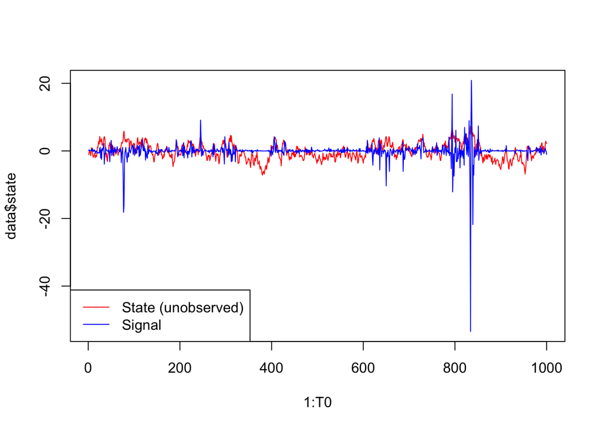

```r
#Removes previously loaded objects
rm(list=ls())

#Sets seed to allow for replication
set.seed(747)

#Function to generate a sample from the stochastic volatility model, given parameters, for T0
#periods
gen_stoch_vol <- function(alpha, beta, sigma, T0)
{
  X = rnorm(1, mean = 0, sd = sigma/sqrt(1-alpha^2) )
  for(t in 1:(T0-1))
    X = c(X, rnorm(1, mean = alpha*X[t], sd = sigma))
  Y = beta*exp(X/2)*rnorm(T0, mean = 0, sd = 1)
  return(list("signal" = Y, "state" = X))
}

#Parameter values
alpha = 0.91
sigma = 1
beta = 0.5
T0 = 1000

#Sample
data = gen_stoch_vol(alpha, beta, sigma, T0)

plot(1:T0, data$state, type = "l", col = "red", ylim =c(min(data$state, data$signal), max(data$state, data$signal)))
lines(1:T0, data$signal, col = "blue")
legend("bottomleft", legend = c("State (unobserved)", "Signal"),  col = c("red","blue"),lty = c(1,1))
```

## Particle Filtering

Suppose we are interested in $p(Y_{1:n}|X_{1:n})$. Observe that, under our assumptions, we have:

$$\begin{align}
p(Y_{1:n},X_{1:n}) = p(Y_{1:n-1},X_{1:n-1})\cdot p(Y_{n}, X_{n}|Y_{1:n-1},X_{1:n-1}) = \\ p(Y_{1:n-1},X_{1:n-1})\cdot p(X_{n}| Y_{1:n-1}, X_{1:n-1}) \cdot p(Y_{n}|Y_{1:n-1}, X_{1:n}) = \\
p(Y_{1:n-1},X_{1:n-1})\cdot f(X_{n}| X_{n-1}) \cdot g(Y_{n}|X_{n})
\end{align}$$

thus

$$\begin{align}
p(X_{1:n}|Y_{1:n})=\frac{p(Y_{1:n-1},X_{1:n-1})\cdot f(X_{n}| X_{n-1}) \cdot g(Y_{n}|X_{n})}{p(Y_{1:n})} =\frac{p(X_{1:n-1}|Y_{1:n-1})\cdot f(X_{n}| X_{n-1}) \cdot g(Y_{n}|X_{n})}{p(Y_{n}|Y_{1:n-1})}
\end{align}$$

where
$$p(Y_{n}|Y_{1:n-1}) = \int p(Y_{n},X_{1:n-1}|Y_{1:n-1}) d X_{1:n-1} = \int p(X_{1:n-1}|Y_{1:n-1})\cdot f(X_{n}| X_{n-1}) \cdot g(Y_{n}|X_{n}) d X_{1:n-1}$$
In Bayesian analysis, we are interested in evaluating the likelihood. This can be done recursively by noticing that:

$$p(Y_{1:n}) = p(Y_1) \prod_{i=2}^n p(Y_{i}|Y_{1:i-1})$$
the difficult thing here is the integral, which is required in each step of the recursion. Particle filtering is a methodology that aims at computing approximations of this difficult likelihood.

In fact, we can put our problem in a broader perspective. Suppose we want to evaluate:

$$\pi(x_{1:n}) = \frac{\gamma_n (x_{1:n})}{Z_n}$$
where we are *able to evaluate* $\gamma_n(x_{1:n})$; and we have $Z_n = \int \gamma_n(x_{1:n}) d x_{1:n}$ (what are these quantities in the Markov model?). Particle filtering (or SMC) will provide an approximation of $\pi(x_{1:n})$ and an estimate of $Z_n$.

### Sequential Importance Sampling

Even if we cannot draw from $\gamma_n$, you’ve learned in class to compute $Z_n$ by importance sampling (choose a density which support contains $\text{supp} \gamma_n$). The problem here is that, for each $n \in \{1,2\ldots T\}$, you’d have to compute $S$ draws of an increasingly larger vector if standard importance sampling were applied. An alternative is sequential importance sampling.

The idea is to use a proposal which can be factored, i.e. $q_n(x_{1:n}) = q_{n-1}(x_{1:n-1})q_n(x_n|x_{1:n-1})$. In this case, weights attached to each draw will be given by:

$$\begin{equation}
\begin{aligned} w_{n}\left(x_{1 : n}\right) &=\frac{\gamma_{n}\left(x_{1 : n}\right)}{q_{n}\left(x_{1 : n}\right)} \\ &=\frac{\gamma_{n-1}\left(x_{1 : n-1}\right)}{q_{n-1}\left(x_{1 : n-1}\right)} \frac{\gamma_{n}\left(x_{1 : n}\right)}{\gamma_{n-1}\left(x_{1 : n-1}\right) q_{n}\left(x_{n} | x_{1 : n-1}\right)} \end{aligned}
\end{equation}$$

and we could write:

$$\begin{equation}
\begin{aligned} w_{n}\left(x_{1 : n}\right) &=w_{n-1}\left(x_{1 : n-1}\right) \cdot \alpha_{n}\left(x_{1 : n}\right) \\=& w_{1}\left(x_{1}\right) \prod_{k=2}^{n} \alpha_{k}\left(x_{1 : k}\right) \end{aligned}
\end{equation}$$

where

$$\begin{equation}
\alpha_{n}\left(x_{1 : n}\right)=\frac{\gamma_{n}\left(x_{1 : n}\right)}{\gamma_{n-1}\left(x_{1 : n-1}\right) q_{n}\left(x_{n} | x_{1 : n-1}\right)}
\end{equation}$$

The algorithm is summarized below.

#### Sequential Importance Sampling Algorithm

For simulations ranging from $s \in \{1,2,\ldots,S\}$:

1. If $n=1$:
- Sample $X_1^s \sim q_1(\cdot)$
- Compute weights $w_1(X_1^s) = \frac{\gamma_1(X_1^s)}{q_1(X_1^s)}$
2. If $n>1$:
- Sample $X_n^s \sim q_n(\cdot|X_{1:n-1}^s)$
- Compute weights $w_n(X_{1:n}^s) = \alpha_{n}\left(X_{1 :n}^s\right) \cdot w_{n-1}(X_{1:n-1}^s)$

Define the normalized weights as:

$$\begin{equation}
W_{n}^{s}=\frac{w_{n}\left(X_{1 : n}^{s}\right)}{\sum_{j=1}^{S} w_{n}\left(X_{1 : n}^{j}\right)}
\end{equation}$$

at the end, we have the following approximations:

$$\begin{equation}
\begin{aligned} \widehat{\pi}_{n}\left(x_{1 : n}\right) &=\sum_{s=1}^{S} W_{n}^{s} \delta_{X_{1 : n}^{s}}\left(x_{1 : n}\right) \\ \widehat{Z}_{n} &=\frac{1}{S} \sum_{s=1}^{S} w_{n}\left(X_{1 : n}^{s}\right) \end{aligned}
\end{equation}$$

the empirical measure $\hat{\pi}_n$ can be used to compute moments.

### Resampling

Ok, we’ve seen how to reduce the computational toll of simulation through sequential importance sampling. For a fixed $n$, we can use the standard apparatus you’ve learned to infer that $\mathbb{E}_{\hat{\pi}_n}[h] = \frac{1}{S} \sum_{s=1}^S W_{n}^{s} h(X_{1 : n}^{s}) \overset{\text{p}}{\to} \int \gamma_n(x_{1:n}) f(x_{1:n}) d x_{1:n}$ as $S \to \infty$ for any $h$ with finite first moments with respect to $\gamma_n$. The problem is that, for a **fixed** S, the approximation error increases as $n$ increases. How can we overcome this?

The idea is to resample from $\hat{\pi}_n$ in order to remove low-weight particles. After we compute $\hat{\pi}_n$, we can draw new $S$ draws from $\hat{\pi}_n$ and compute a resulting empirical measure $\bar{\pi}_n$. This is equivalent to drawing weights $(S^s_n)_{s=1}^S$ from a multinomial distribution with parameters $S$ and $(W^s_n)_{s=1}^S$ and then computing.

$$\begin{equation}
\overline{\pi}_{n}\left(x_{1 : n}\right)=\sum_{s=1}^{S} \frac{S_{n}^{s}}{S} \delta_{X_{1 : n}^{s}}\left(x_{1 : n}\right)
\end{equation}$$

there are more refined methods to resample. Cf. the survey for details.

### Sequential Monte Carlo

Particle filtering alternates between SIC and Resampling. Here we outline the simplest algorithm:

#### Sequential Monte Carlo Algorithm

For each $n \in \{1,2,\ldots,T\}$:

1. If $n=1$:
- For iterations $s \in \{1,2,\ldots, S\}$, draw $X_1^s \sim q_1(\cdot)$
- Compute the weights $w_1(X_1^s)$ and the normalized weights $W_1(X_1^s)$
- Resample from $\{W_1^s, X_1^s\}$ to obtain a resampled sample $\left\{\bar{W}_1^s = \frac{1}{S}, \bar{X}_1^s\right\}$
2. If $n>1$:
- For iterations $s \in \{1,2,\ldots, S\}$, draw $X_{n}^s \sim q_1(\cdot|\bar{X}_{1:n-1}^s)$ and set $X_{1:n}^s := (\bar{X}_{1:n-1}^s, X_{n}^s)$
- Compute the weights $w_n(X_{1:n}^{s}) := \alpha_{n}\left(X_{1 :n}^{s}\right)$ and the normalized weights $W_{n}^{s}=\frac{w_{n}\left(X_{1 : n}^{s}\right)}{\sum_{j=1}^{S} w_{n}\left(X_{1 : n}^{j}\right)}$
- Resample from $\{W_n^s, X_{1:n}^s\}$ to obtain a resampled sample $\left\{\bar{W}_n^s = \frac{1}{S}, \bar{X}_{1:n}^s\right\}$

At each step, we have the following approximations to $\pi_n(x_{1:n})$:

$$\begin{equation}
\widehat{\pi}_{n}\left(x_{1 : n}\right)=\sum_{i=1}^{N} W_{n}^{i} \delta_{X_{1 : n}^{i}}\left(x_{1 : n}\right)
\end{equation}$$

$$\begin{equation}
\overline{\pi}_{n}\left(x_{1 : n}\right)=\frac{1}{N} \sum_{i=1}^{N} \delta_{\overline{X}_{1 : n}^{i}}\left(x_{1 : n}\right)
\end{equation}$$

the former is to be preferred to the latter (why?).

We will apply the model to compute the likelihood of the stochastic volatility model. Our proposals will be

$$q_1(\cdot) \sim \mathcal{N}\left(0, \frac{\sigma^2}{1-\alpha^2}\right)$$
$$q_n(\cdot|X_{1:n}^s) \sim \mathcal{N}\left(\alpha X_{t-1}, \sigma^2 \right)$$

The function below computes the model log-likelihood

```r
#Page 19 of Doucet-Johansen
particle_filter_likelihood <- function(signal, alpha, sigma, beta, S = 100)
{
  log_lkl = 0
  for(t in 1:length(signal))
  {
  if(t==1)
    X_t =rnorm(S,mean = 0, sd = sigma/sqrt(1-alpha^2)) else
      X_t = rnorm(S,mean = alpha*X_t_1, sd = sigma)

    update_weight =dnorm(signal[t], mean = 0, sd = beta^2*exp(X_t/2))

    log_lkl = log_lkl + log(mean(update_weight))

    #print(update_weight)
    #Resample
    X_t_bar = sample(X_t, S, replace = T,  prob = update_weight)
    X_t_1 = X_t_bar

  }
  return(log_lkl)
}
```